# I’m an Autistic Woman, and These 7 Stereotypes About Autism Are Flat-Out Wrong

June 8, 2023

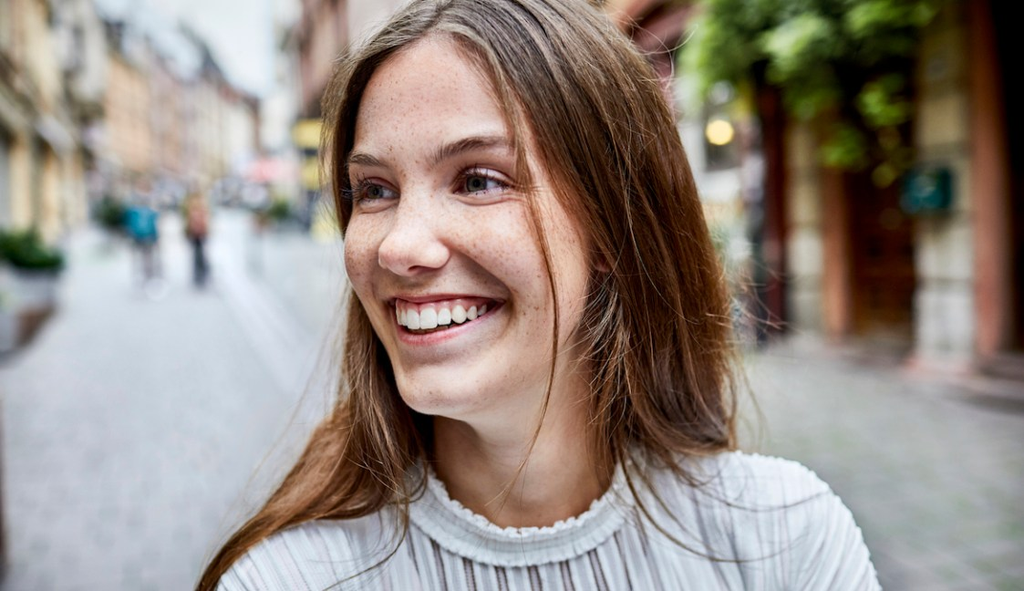

Photo: Getty Images / Oliver Rossi

I used to think I couldn’t possibly [be autistic](https://www.wellandgood.com/self-care-autism/). As far as I was concerned, autistic people are typically men, can’t connect with other people, and are obsessed with trains and cars, right? Not so. I have since learned that I am autistic despite not having these traits, which represent a stereotype of autistic people more than an accurate characterization.

Many people form a concept of autism—a neurotype (type of brain) that processes social and sensory information differently from the majority of people—based on movies like *Rain Man* (whose protagonist is inspired by someone who [was not even autistic](https://www.aruma.com.au/about-us/blog/get-to-know-the-real-rain-man-kim-peek/)) rather than real-life interactions with people with autism. Stereotypes about autism can prevent those who don’t fit them from realizing they’re autistic, which means that they may not receive the support they need, or may have other, more stigmatizing labels put on them. Stereotypes can also cause autistic people to feel like something is wrong with them. Not to mention, they perpetuate pathologizing beliefs about autism, e.g. that it is caused by vaccines.

Experts In This Article

- [Ari Wolf](https://www.wellandgood.com/autism-myths/)
- [Eleanor Bennett](https://www.competitiveinsight.io/)
- [Kjirsten Broughton](https://www.speechbuddy.com/speech-therapy/profile/b242cba46cda72d/kjirsten-broughton)
- [LaQuista Erinna, DBH, LCSW](https://laquistaerinna.com/)
- [Russell Lehmann](https://russl.co/)
- [Ryan Sultan, MD](https://www.integrativepsych.nyc/experts/dr-ryan-sultan), assistant professor of clinical psychiatry and director of the Mental Health Informatics Lab at Columbia University

Some stereotypes about autistic people have a grain of truth to them but are misunderstood, some are true for a portion of autistic people but not others, and some are outright wrong. Here are a few common autism myths and misconceptions that are worth questioning.

## 1. Myth: Autistic people don’t care about other people.

Fact: When many people think of autism, they picture someone who lacks empathy. This can make the label of “autistic” very stigmatizing, as it implies that autistic people are unkind or uncaring. In reality, the [diagnostic criteria for autism](https://www.cdc.gov/ncbddd/autism/hcp-dsm.html) say nothing about empathy.

Some autistic people do have different patterns of empathizing than others, but that doesn’t mean they don’t empathize at all. For instance, I don’t usually have strong feelings in response to world events, as my practical brain prefers to focus on things in my immediate environment—but this doesn’t mean I don’t empathize with people close to me.

Other autistic people may not always empathize with those around them, but this is often due to a lack of understanding rather than a lack of caring. “I have a great deal of empathy once I understand the context of a situation,” says Eleanor Bennett, an autistic 27-year-old in Cambridge, UK and founder of [Competitive Insight](https://competitiveinsight.io/). We *want* to be there for people and help them; we just may need the chance to learn how to do so.

“Autistic individuals are fully capable of empathy and can even experience hyper-empathy, where they feel overwhelming pain, both emotionally and physically, at just the thought of someone else's suffering,” says [Kjirsten Broughton](https://www.speechbuddy.com/speech-therapy/profile/b242cba46cda72d/kjirsten-broughton), a neurodivergent speech and language pathologist specializing in autism. “Many autistic individuals often exhibit hyper-empathy toward animals.” Ari Wolf, a 34-year-old autistic graduate student in Eugene, Oregon, identifies as hyper-empathetic, explaining, “we simply express this empathy differently from most people.” For example, Wolf says that an autistic person might respond to someone’s story about their pain by telling a story about a time they’ve felt similarly. “We view this as an experience of empathy, but it is rarely received that way.”

## 2. Myth: Relationships aren’t important to autistic people

Autistic people are often seen as loners or anti-social, but we need human connection just like everyone else. Many of us are simply wary of others due to the mistreatment we’ve received in the past.

“The reason, personally, that it might seem like I don't want a close relationship is because, to be blunt, people scare me,” says autistic motivational speaker [Russell Lehmann](https://russl.co/). “I have been hurt a lot by this world, due to the naïveté, purity, innocence, and fragility of being on the spectrum. Something as simple as a smile not being returned can leave a paper cut on my heart.”

Some of us enjoy spending time alone because social activities are overwhelming to us or because we are engrossed in our special interests—topics and activities autistic people are extremely passionate about. But this doesn’t mean we don’t want any friends, close family relationships, or romantic relationships. In fact, research shows that autistic people [experience loneliness more often](https://journals.sagepub.com/doi/full/10.1177/13623613221077721) than neurotypical people, probably because others so often exclude us. While some autistic people may need lots of time to ourselves, we still appreciate feeling wanted and included.

## 3. Myth: Autistic people lack social skills

Given that one [diagnostic criterion for autism](https://www.cdc.gov/ncbddd/autism/hcp-dsm.html) is “persistent deficits in social communication and social interaction,” it’s understandable that people often assume autism entails a lack of social skills. However, the criterion itself is problematic: Who decides what counts as a deficit? Usually, it is neurotypical people. What a neurotypical person might call a deficit, autistic people may simply call a difference.

“It is extremely common for any dominant social group to demean and dismiss the marginalized social group's preferred form of communication,” Wolf points out. “Misogynistic men often mock or belittle women's voices as too sharp, too domineering, too shrewish, too whatever.” Similarly, the denigration of autistic people’s social behavior as inept or awkward may be more political than scientific.

“While some autistic individuals may face challenges in social interactions and communication with neurotypical individuals, it is important to note that these challenges are not one-sided,” Broughton explains. “Neurotypical individuals also encounter difficulties when communicating with autistic people.” In other words, it’s not that autistic people can’t communicate—it’s that autistic people have trouble communicating withneurotypical people, and vice versa.

This isn’t always the case either, though. Many autistic people, [especially autistic women](https://www.psychologytoday.com/us/blog/women-autism-spectrum-disorder/202104/masking-and-mental-health-in-women-autism), learn to “mask”—that is, mimic the speech, body language, and social behavior of neurotypical people. This may not come naturally to us, but we do it in order to fit in, which can cause us to exhibit the same social skills as neurotypical people. Masking can be emotionally taxing for autistic people and is part of the reason why many of us shy away from social situations.

## 4. Myth: Autism is a male characteristic

Autism is often stereotyped as a male condition, leading many women and non-binary people to go undiagnosed. (I was not diagnosed until my thirties). However, while it’s true that men dominate autism diagnoses, [recent research](https://pubmed.ncbi.nlm.nih.gov/28545751/) has shown that autism is more common in women than previously believed—and [we may still not even know how common it is](https://www.theguardian.com/society/2018/sep/14/thousands-of-autistic-girls-and-women-going-undiagnosed-due-to-gender-bias). Part of the reason for this is that men’s autistic traits can sometimes be more visible. Autism often [shows up differently in women](https://health.clevelandclinic.org/for-females-with-autism-differences-matter/), as women are more likely to learn conventional social behavior by observing others and engage in masking.

Because of autistic women’s tendency to mask and because of clinicians’ bias toward diagnosing men, autism in women is likely [vastly underestimated](https://www.wellandgood.com/autistic-women-adult-diagnosis/), which means many women go years (or their whole lives) without help navigating the world as an autistic person. Women are also [frequently misdiagnosed](https://www.psychologytoday.com/us/blog/talking-about-trauma/201905/why-women-autism-so-often-are-misdiagnosed), sometimes with stigmatized conditions like borderline personality disorder. In addition, trans and non-binary people are more likely than cis people to be autistic, yet this population is often left out of discussions about autism.

Along the same lines, autistic people do not universally have stereotypically “masculine” interests such as math and science. While many autistic people do have particular interests (which, again, are not unique to men), these interests can include anything from fashion to theater to movies.

## 5. Myth: Autistic people are violent

Unfortunately, after a violent crime is in the news, you sometimes hear rumors that the perpetrator was autistic. (Think back, for instance, to internet speculation that the [mass shooter Elliot Rodger was autistic](https://www.forbes.com/sites/emilywillingham/2014/05/30/elliot-rodger-didnt-have-autism-he-had-anger/?sh=7017aaec4b91).) “This stereotype is not only inaccurate, but it is also harmful,” says [Ryan Sultan, MD](https://www.integrativepsych.nyc/experts/dr-ryan-sultan), a psychiatrist and researcher at Columbia University. The view of autistic people as aggressive can lead to many problems including bullying, exclusion, employment discrimination, and even violence toward autistic people, he explains.

“Autistic people are no more likely to be violent or aggressive than anyone else,” says Dr. Sultan. Indeed, a 2018 study in *Frontiers in Psychiatry* found that autistic people were [no more likely than neurotypical people](https://www.ncbi.nlm.nih.gov/pmc/articles/PMC5980973/) to commit crimes. Autistic people are, however, more likely to be the victims of crimes, including sexual assault and physical violence.

## 6. Myth: There is such a thing as “looking autistic”

Some autistic people get told they “don’t look autistic,” which not only invalidates their identity but also reflects a misunderstanding of autism. “Autism does not have a look,” says [LaQuista Erinna, DBH, LCSW,](https://laquistaerinna.com/) a psychotherapist and mother of an autistic son. “Every autistic individual is different and will present themself in their own unique way.”

And contrary to media stereotypes, there is no one way to act autistic. Autistic people have a wide range of personalities, interests, and characteristics. “Each person with autism is unique and may experience different challenges and strengths,” says Dr. Sultan. That’s why it’s called the autism spectrum; it includes a wide range of people and experiences.

## 7. Myth: Being autistic is a bad thing

I have personally had people tell me “you don’t seem autistic” as if it is a compliment, but I don’t see it that way. I personally take it as a compliment when someone sees that I am autistic! It means they see that I’m unique, passionate, delightfully quirky, and fiercely individualistic—and, more simply, that they see me as I am. And who I am is a beautiful thing to celebrate, not a deficit to put down.

Tags: [Healthy Mind](https://www.wellandgood.com/healthy-mind/), [Mental Challenges](https://www.wellandgood.com/mental-challenges/)

[Health](https://www.wellandgood.com/health/) [Healthy Body](https://www.wellandgood.com/healthy-body/)